# ML Project

January 31, 2016

#### **Background**

Using devices such as Jawbone Up, Nike FuelBand, and Fitbit it is now possible to collect a large amount of data about personal activity relatively inexpensively. These type of devices are part of the quantified self movement – a group of enthusiasts who take measurements about themselves regularly to improve their health, to find patterns in their behavior, or because they are tech geeks. One thing that people regularly do is quantify how much of a particular activity they do, but they rarely quantify how well they do it.

In this project, our goal will be to use data from accelerometers on the belt, forearm, arm, and dumbell of 6 participants. They were asked to perform barbell lifts correctly and incorrectly in 5 different ways. More information is available from the website here: http://groupware.les.inf.puc-rio.br/har (see the section on the Weight Lifting Exercise Dataset).

#### **Data**

The training data for this project are available here:

https://d396qusza40orc.cloudfront.net/predmachlearn/pml-training.csv

The test data are available here:

https://d396qusza40orc.cloudfront.net/predmachlearn/pml-testing.csv

The data for this project come from this source: http://groupware.les.inf.puc-rio.br/har. If you use the document you create for this class for any purpose please cite them as they have been very generous in allowing their data to be used for this kind of assignment.

Required libraries (if not present on your machine please use install.packages (“libraryname”) to install them)

```r
library(caret)
```

```r
library(rpart)
library(rpart.plot)
library(RColorBrewer)
library(rattle)
library(randomForest)
```

#### **Getting data**

```r
download.file(url="https://d396qusza40orc.cloudfront.net/predmachlearn/pml-training.csv", destfile="pml-training.csv", method="curl")
download.file(url="https://d396qusza40orc.cloudfront.net/predmachlearn/pml-testing.csv", destfile="pml-testing.csv", method="curl")


training <- read.csv("pml-training.csv", na.strings=c("NA","#DIV/0!", ""))
testing <- read.csv("pml-testing.csv", na.strings=c("NA","#DIV/0!", ""))
```

#### **Exploratory analysis**

```r
#dim(training); dim(testing); summary(training); summary(testing); str(training); str(testing); head(training); #head(testing);
```

#### **Removing columns with all missing values**

```r
training<-training[,colSums(is.na(training)) == 0]
testing <-testing[,colSums(is.na(testing)) == 0]

# Removing irrelevant variables user_name, raw_timestamp_part_1, raw_timestamp_part_,2 cvtd_timestamp, new_window, and  num_window (columns 1 to 7).
training   <-training[,-c(1:7)]
testing <-testing[,-c(1:7)]
```

#### **Partition the data so that 80% of the training dataset into training and the remaining 20% to testing**

```r
traintrainset <- createDataPartition(y=training$classe, p=0.80, list=FALSE)
TrainingSet <- training[traintrainset, ]
TestingSet <- training[-traintrainset, ]
```

#### **Models and predictions**

```r
model1 <- rpart(classe ~ ., data=TrainingSet, method="class")

prediction1 <- predict(model1, TestingSet, type = "class")
confusionMatrix(prediction1, TestingSet$classe)
```

```
## Confusion Matrix and Statistics
##
##           Reference
## Prediction    A    B    C    D    E
##          A 1013  120   18   34   11
##          B   36  456   78   59   85
##          C   35   99  540   91   96
##          D   16   68   48  408   42
##          E   16   16    0   51  487
##
## Overall Statistics
##
##                Accuracy : 0.7402
##                  95% CI : (0.7262, 0.7539)
##     No Information Rate : 0.2845
##     P-Value [Acc > NIR] : < 2.2e-16
##
##                   Kappa : 0.6707
##  Mcnemar's Test P-Value : < 2.2e-16
##
## Statistics by Class:
##
##                      Class: A Class: B Class: C Class: D Class: E
## Sensitivity            0.9077   0.6008   0.7895   0.6345   0.6755
## Specificity            0.9348   0.9185   0.9009   0.9470   0.9741
## Pos Pred Value         0.8470   0.6387   0.6272   0.7010   0.8544
## Neg Pred Value         0.9622   0.9056   0.9530   0.9297   0.9302
## Prevalence             0.2845   0.1935   0.1744   0.1639   0.1838
## Detection Rate         0.2582   0.1162   0.1376   0.1040   0.1241
## Detection Prevalence   0.3049   0.1820   0.2195   0.1484   0.1453
## Balanced Accuracy      0.9213   0.7596   0.8452   0.7907   0.8248
```

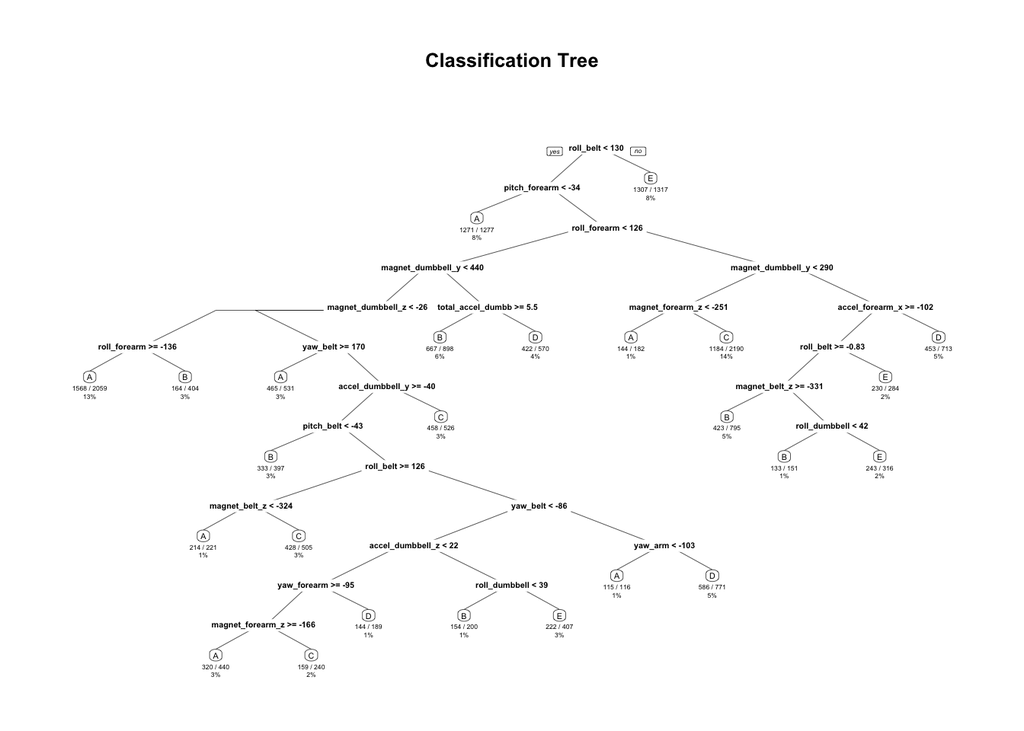

```r
# Plot the Decision Tree
rpart.plot(model1, main="Classification Tree", extra=102, under=TRUE, faclen=0)
```

```r
model2 <- randomForest(classe ~. , data=TrainingSet, method="class")

# Predicting:
prediction2 <- predict(model2, TestingSet, type = "class")
confusionMatrix(prediction2, TestingSet$classe)
```

```
## Confusion Matrix and Statistics
##
##           Reference
## Prediction    A    B    C    D    E
##          A 1115    0    0    0    0
##          B    1  759    2    0    0
##          C    0    0  681    5    0
##          D    0    0    1  638    1
##          E    0    0    0    0  720
##
## Overall Statistics
##
##                Accuracy : 0.9975
##                  95% CI : (0.9953, 0.9988)
##     No Information Rate : 0.2845
##     P-Value [Acc > NIR] : < 2.2e-16
##
##                   Kappa : 0.9968
##  Mcnemar's Test P-Value : NA
##
## Statistics by Class:
##
##                      Class: A Class: B Class: C Class: D Class: E
## Sensitivity            0.9991   1.0000   0.9956   0.9922   0.9986
## Specificity            1.0000   0.9991   0.9985   0.9994   1.0000
## Pos Pred Value         1.0000   0.9961   0.9927   0.9969   1.0000
## Neg Pred Value         0.9996   1.0000   0.9991   0.9985   0.9997
## Prevalence             0.2845   0.1935   0.1744   0.1639   0.1838
## Detection Rate         0.2842   0.1935   0.1736   0.1626   0.1835
## Detection Prevalence   0.2842   0.1942   0.1749   0.1631   0.1835
## Balanced Accuracy      0.9996   0.9995   0.9970   0.9958   0.9993
```

Model2 has higher accuracy

#### **Final Prediction**

```r
finalprediction <- predict(model2, testing, type="class")
finalprediction
```

```
##  1  2  3  4  5  6  7  8  9 10 11 12 13 14 15 16 17 18 19 20
##  B  A  B  A  A  E  D  B  A  A  B  C  B  A  E  E  A  B  B  B
## Levels: A B C D E
```

#### **Write the results to a text file for submission**

```r
pml_write_files = function(x){
    n = length(x)
    for(i in 1:n){
        filename = paste0("problem_id_",i,".txt")
        write.table(x[i],file=filename,quote=FALSE,row.names=FALSE,col.names=FALSE)
    }
}
pml_write_files(finalprediction)
```